# 消費者信心指數之分析

December 29, 2016

## 研究動機

- 近年來經濟是台灣人最擔憂問題之一，社會蔓延著一股悲觀的氛圍
- 我們想透過消費者信心指數（Consumer Confidence Index）來評估整個社會環境中消費者對經濟的評價與期待，檢視這些擔憂究竟只是部分族群被放大後的聲音，還是社會確實普遍瀰漫著一股對未來經濟的不確定?
- 利用時間序列分析未來可能的走勢

## 消費者信心指數(CCI)

- 消費者信心指數是指消費者對目前經濟的評價及預期未來經濟趨勢的指標
- 通過抽樣調查，量化民眾對經濟及個人財務的感覺，其數值越高，表示民眾對經濟情況越樂觀
- 點數於0~200間
  - 100-200 ➔ 樂觀預期
  - 0-100 ➔ 信心保守。
- 由於消費者對經濟的信心會影響消費活動，故消費者信心指數為總體經濟的其中一項重要指標

## 時間序列圖

[figure not shown]

## 盒狀圖

```
##    Min. 1st Qu.  Median    Mean 3rd Qu.    Max.
##   48.42   68.14   75.85   74.06   80.18   92.93
```

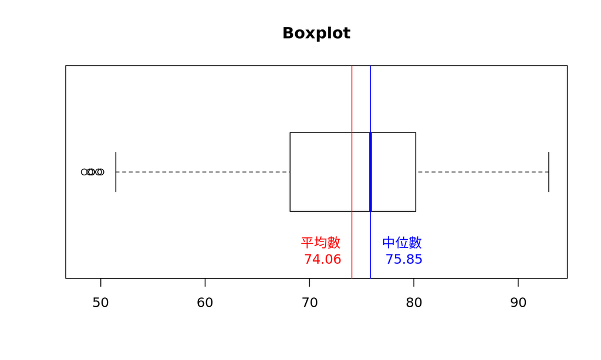

## 分析過程

## Box-Jenkins Model Section三步驟

- Identification Stage
  - 畫圖
  - Unit Root Test
  - ACF
  - PACF
- Estimation Stage
  - ARIMA(p,d,q)
- Diagnostic Stage
  - AIC
  - BIC
  - Q-statistics

## 刪除1999及2000的季資料

[interactive chart not shown]

## Unit Root Test

### Dickey-Fuller Test

\(H_0:有單根\) , \(H_1:無單根\)

| method | p-value |
| --- | --- |
| trend | 0.1743 |
| drift | 0.1300 |
| none | 0.7026 |

三次單根檢定都不拒絕H0 ➔ 非定態

## Unit Root Test

### Phillips-Perron Test

\(H_0:有單根\) , \(H_1:無單根\)

```
##
##  Phillips-Perron Unit Root Test
##
## data:  x1$數值
## Dickey-Fuller = -2.1517, Truncation lag parameter = 4, p-value =
## 0.5127
```

p-value = 0.5127 ➔ Do not reject \(H_0\) ➔ 非定態 ➔ 差分

## 考慮一次差分

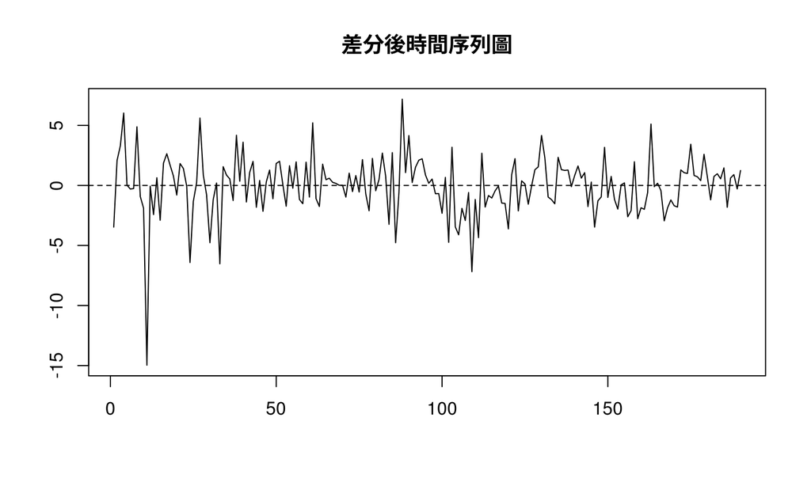

## 差分後的Unit Root Test

### Dickey-Fuller Test

\(H_0:有單根\) , \(H_1:無單根\)

| method | p-value |
| --- | --- |
| trend | 0.0000 |
| drift | 0.0000 |
| none | 0.0000 |

Reject \(H_0\) ➔ 拒絕單根假設

## 差分後的Unit Root Test

### Phillips-Perron Test

\(H_0:有單根\) , \(H_1:無單根\)

```
##
##  Phillips-Perron Unit Root Test
##
## data:  x3
## Dickey-Fuller = -12.981, Truncation lag parameter = 4, p-value =
## 0.01
```

p-value = 0.01 ➔ Reject \(H_0\) ➔ 拒絕單根假設

## ACF

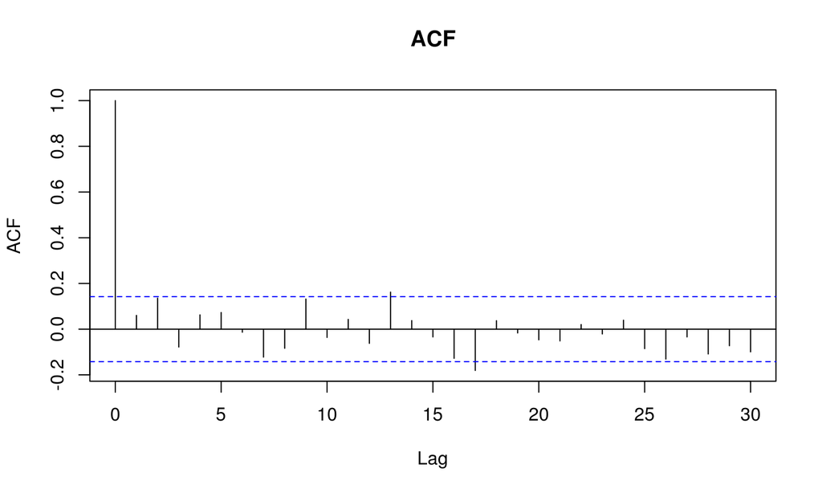

## PACF

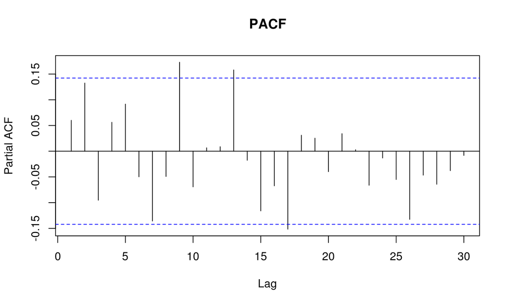

## 資料切割

Training ➔ 前179筆(94%)

Testing ➔ 最後12筆(6%)

## 選出三個候選model

分別是：ARMA(0,0)、ARMA(2,2)、ARMA(2,4)

### ！！！Q統計量我未改

| 項目 | ARMA(0,0) | ARMA(2,2) | ARMA(2,4) |
| --- | --- | --- | --- |
| AIC | 835.7767 | 832.9160 | 824.1821 |
| BIC | 838.9585 | 848.8249 | 846.4546 |
| pvalue(Q(18)) | 0.0161 | 0.0667 | 0.1463 |
| pvalue(Q(12)) | 0.1677 | 0.3714 | 0.1887 |

### 因為是預測原資料而非差分資料，此頁可能刪除

## Residual Diagnostic

## Residual Diagnostic

### ACF & PACF of Residuals

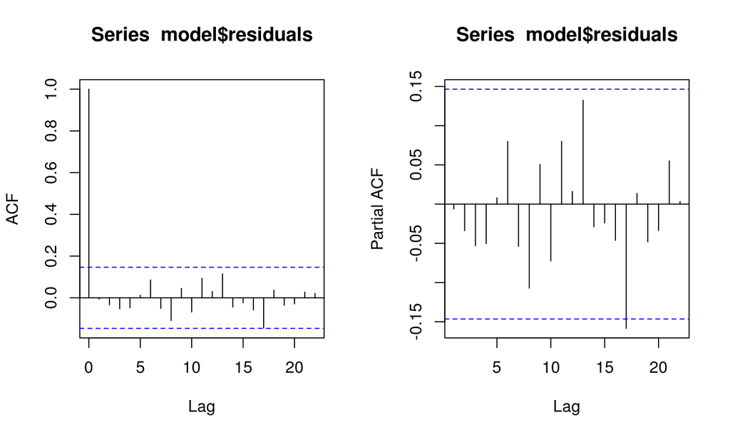

```
##
##  Phillips-Perron Unit Root Test
##
## data:  model$residuals
## Dickey-Fuller = -13.339, Truncation lag parameter = 4, p-value =
## 0.01
```

```
##
##  Box-Ljung test
##
## data:  model$residuals
## X-squared = 0.0071194, df = 1, p-value = 0.9328
```

## 配適值與實際值比較

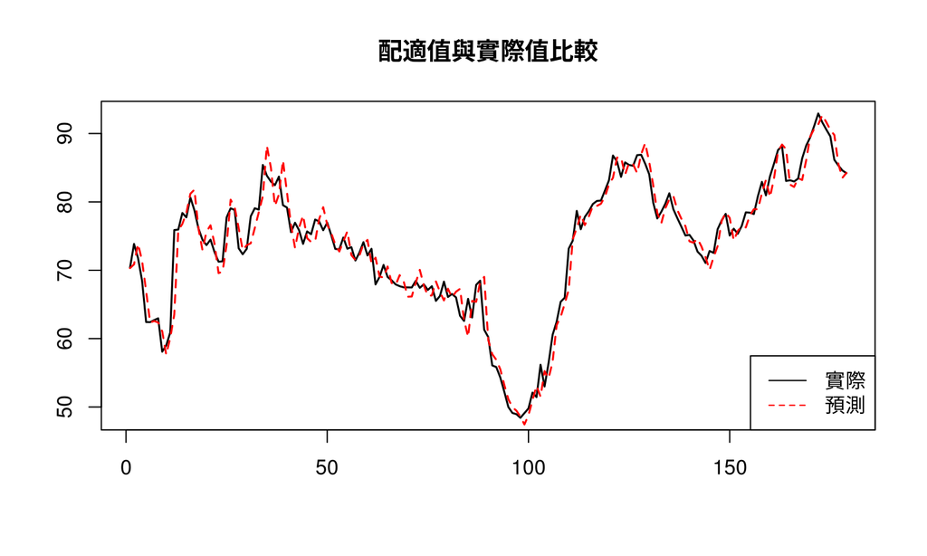

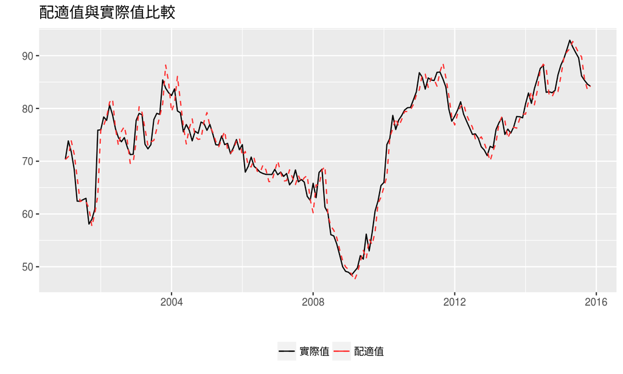

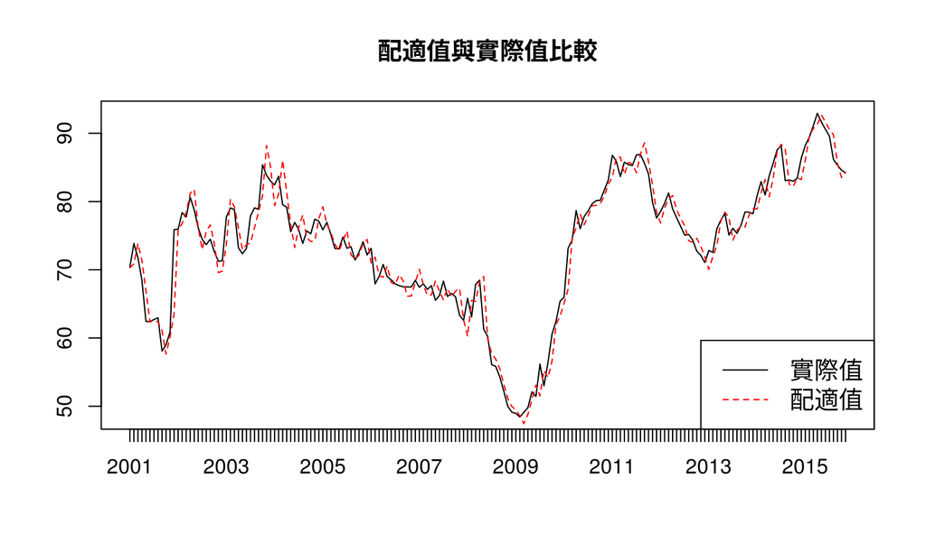

## 預測值與實際值比較(95%C.I.)

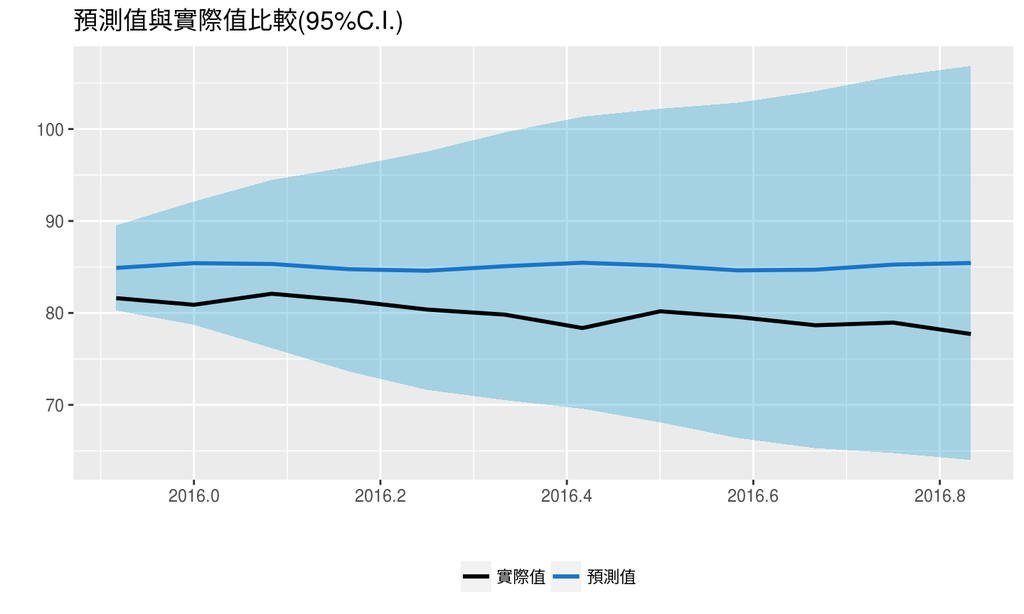

```
## [1] 6.405292
```

```
## [1] 5.289908
```

## 結論

- CCI大部份都在50-100之間，表示民眾長期對於未來經濟信心保守
- 資料切點剛好在一波上升後，可能導致預測過度樂觀
- 難以預測民眾對於未來經濟評價